# Helpfulness Movies

zdenek.vesely@gmail.com

1/20/2020

Each review can have up-votes (= positive votes) or down-votes (= negative votes).

My personal definition:

- the review is helpful positive if it has at least 3 up-votes and there is at least 80% positive votes
- the review is helpful negative (spam) if it has at least 3 down-votes and there is at least 80% negative votes

## Helpfulness by stars

Large percentage of the reviews has no helpful score:

| stars | helpful_positive_n | helpful_positive_perc | helpful_negative_n | helpful_negative_perc | n_reviews |
| --- | --- | --- | --- | --- | --- |
| 1 | 6912 | 0.07 | 23046 | 0.23 | 101889 |
| 2 | 6741 | 0.07 | 13725 | 0.14 | 100231 |
| 3 | 20622 | 0.10 | 13654 | 0.07 | 197082 |
| 4 | 61733 | 0.16 | 7618 | 0.02 | 375835 |
| 5 | 139607 | 0.16 | 13230 | 0.01 | 892669 |

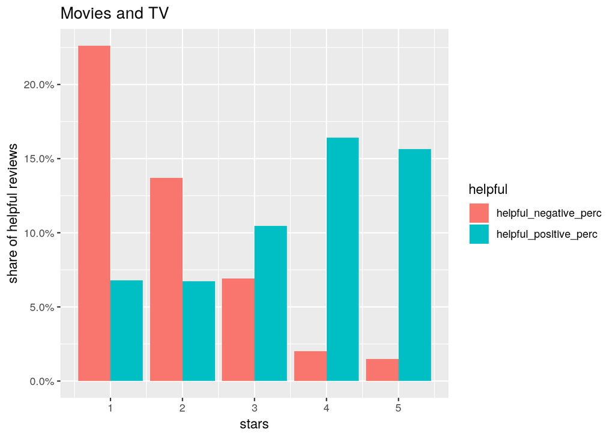

## Words (tokens)

We can tokenize the review texts and look into what kind of words are associated with positive/negative reviews or with helpful/spam reviews.

### Stars

The most positive and most negative frequent words:

| review_tokens | stars | helpful_positive_1 | helpful_negative_1 | n_obs |
| --- | --- | --- | --- | --- |
| timeless | 4.6267 | 0.2897 | 0.0158 | 8939 |
| unforgett | 4.6227 | 0.3606 | 0.0140 | 7641 |
| superb | 4.5600 | 0.2862 | 0.0164 | 39631 |
| heartwarm | 4.5558 | 0.2286 | 0.0124 | 4518 |
| bravo | 4.5553 | 0.2800 | 0.0242 | 4007 |
| superbl | 4.5463 | 0.3488 | 0.0120 | 5006 |
| finest | 4.5326 | 0.3426 | 0.0154 | 13852 |
| flawless | 4.5218 | 0.3057 | 0.0146 | 8977 |
| outstand | 4.5087 | 0.2736 | 0.0162 | 29503 |
| awesom | 4.5081 | 0.1431 | 0.0278 | 46010 |
| grandson | 4.5075 | 0.1258 | 0.0172 | 4548 |
| mesmer | 4.5031 | 0.3173 | 0.0168 | 5834 |
| exquisit | 4.4964 | 0.3964 | 0.0152 | 4728 |
| priceless | 4.4889 | 0.3183 | 0.0160 | 5177 |
| favorit | 4.4876 | 0.2149 | 0.0200 | 113673 |
| bland | 2.9919 | 0.1773 | 0.0704 | 6764 |
| insult | 2.9767 | 0.1981 | 0.0758 | 9093 |
| stupid | 2.9733 | 0.1272 | 0.1053 | 33104 |
| forgett | 2.9098 | 0.1509 | 0.0720 | 4876 |
| redeem | 2.9065 | 0.1569 | 0.0830 | 9691 |
| tedious | 2.8881 | 0.1570 | 0.0943 | 5470 |
| pathet | 2.8630 | 0.1804 | 0.0982 | 7803 |
| aw | 2.8243 | 0.1757 | 0.0830 | 23096 |
| lousi | 2.8153 | 0.1781 | 0.0973 | 4060 |
| lame | 2.7760 | 0.1299 | 0.1041 | 13225 |
| worst | 2.7632 | 0.1640 | 0.0948 | 37425 |
| laughabl | 2.7515 | 0.1508 | 0.0828 | 7399 |
| pointless | 2.7188 | 0.1456 | 0.0938 | 8653 |
| garbag | 2.6401 | 0.1481 | 0.1274 | 8716 |
| wast | 2.4123 | 0.1247 | 0.1252 | 40783 |

### Helpful positive

The most and least helpful frequent words:

| review_tokens | stars | helpful_positive_1 | helpful_negative_1 | n_obs |
| --- | --- | --- | --- | --- |
| booklet | 4.4607 | 0.4647 | 0.0165 | 4489 |
| beginn | 4.2458 | 0.4614 | 0.0084 | 5501 |
| orchestra | 4.3497 | 0.4547 | 0.0205 | 4775 |
| yoga | 4.2457 | 0.4537 | 0.0137 | 5819 |
| archiv | 4.2177 | 0.4423 | 0.0172 | 4538 |
| cardio | 4.3258 | 0.4419 | 0.0055 | 4377 |
| stereo | 4.1657 | 0.4367 | 0.0178 | 5113 |
| anamorph | 3.9136 | 0.4354 | 0.0190 | 4538 |
| galleri | 4.2967 | 0.4319 | 0.0117 | 7152 |
| mgm | 4.0772 | 0.4222 | 0.0193 | 6701 |
| print | 4.0579 | 0.4196 | 0.0205 | 19980 |
| instructor | 4.1555 | 0.4177 | 0.0166 | 6507 |
| historian | 4.2189 | 0.4173 | 0.0265 | 4385 |
| instruct | 4.1216 | 0.4145 | 0.0172 | 6857 |
| restor | 4.2607 | 0.4103 | 0.0167 | 18579 |
| stupid | 2.9733 | 0.1272 | 0.1053 | 33104 |
| grandson | 4.5075 | 0.1258 | 0.0172 | 4548 |
| damon | 3.9102 | 0.1252 | 0.0484 | 5478 |
| crap | 3.0011 | 0.1249 | 0.1102 | 10891 |
| wast | 2.4123 | 0.1247 | 0.1252 | 40783 |
| netflix | 3.9343 | 0.1203 | 0.0422 | 5237 |
| depp | 4.0043 | 0.1197 | 0.0539 | 7129 |
| pixar | 4.2445 | 0.1194 | 0.0421 | 4061 |
| dont | 3.7479 | 0.1179 | 0.1024 | 13491 |
| bullock | 3.9249 | 0.1136 | 0.0353 | 4103 |
| cant | 4.0587 | 0.1031 | 0.0836 | 7479 |
| lol | 4.1715 | 0.1005 | 0.0561 | 8929 |
| denzel | 4.0808 | 0.0989 | 0.0353 | 4591 |
| didnt | 3.6273 | 0.0928 | 0.0971 | 6219 |
| im | 3.9781 | 0.0908 | 0.0924 | 7070 |

### Helpful negative

The most and least spam related frequent words:

| review_tokens | stars | helpful_positive_1 | helpful_negative_1 | n_obs |
| --- | --- | --- | --- | --- |
| garbag | 2.6401 | 0.1481 | 0.1274 | 8716 |
| wast | 2.4123 | 0.1247 | 0.1252 | 40783 |
| asleep | 3.0089 | 0.1364 | 0.1206 | 5852 |
| crap | 3.0011 | 0.1249 | 0.1102 | 10891 |
| bore | 3.0350 | 0.1401 | 0.1085 | 61257 |
| junk | 3.0438 | 0.1805 | 0.1077 | 4858 |
| stupid | 2.9733 | 0.1272 | 0.1053 | 33104 |
| lame | 2.7760 | 0.1299 | 0.1041 | 13225 |
| dont | 3.7479 | 0.1179 | 0.1024 | 13491 |
| suck | 3.1905 | 0.1392 | 0.1014 | 16276 |
| pathet | 2.8630 | 0.1804 | 0.0982 | 7803 |
| lousi | 2.8153 | 0.1781 | 0.0973 | 4060 |
| didnt | 3.6273 | 0.0928 | 0.0971 | 6219 |
| trash | 3.1081 | 0.1799 | 0.0970 | 10424 |
| worst | 2.7632 | 0.1640 | 0.0948 | 37425 |
| featurett | 4.2221 | 0.3605 | 0.0143 | 14221 |
| delight | 4.4534 | 0.3123 | 0.0141 | 28521 |
| gentl | 4.3805 | 0.3691 | 0.0141 | 8003 |
| unforgett | 4.6227 | 0.3606 | 0.0140 | 7641 |
| crisp | 4.3580 | 0.3556 | 0.0140 | 8959 |
| yoga | 4.2457 | 0.4537 | 0.0137 | 5819 |
| underst | 4.2958 | 0.3334 | 0.0136 | 5156 |
| poignant | 4.4588 | 0.3418 | 0.0126 | 8857 |
| heartwarm | 4.5558 | 0.2286 | 0.0124 | 4518 |
| heartbreak | 4.4799 | 0.3533 | 0.0124 | 6476 |
| superbl | 4.5463 | 0.3488 | 0.0120 | 5006 |
| galleri | 4.2967 | 0.4319 | 0.0117 | 7152 |
| workout | 4.3168 | 0.3841 | 0.0112 | 16489 |
| beginn | 4.2458 | 0.4614 | 0.0084 | 5501 |
| cardio | 4.3258 | 0.4419 | 0.0055 | 4377 |

## Review length

Distribution of the review length.

### Stars

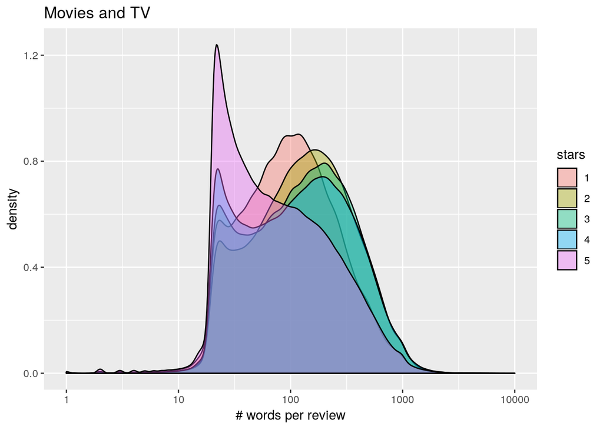

### Helpfulness positive

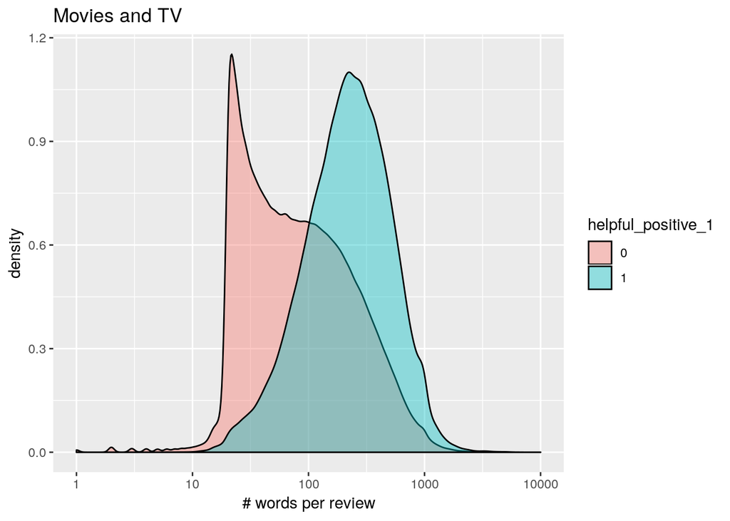

### Helpfulness negative

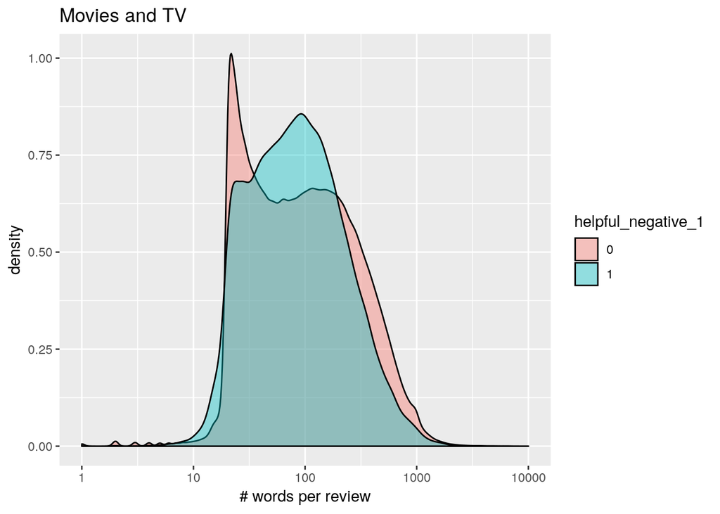

## Review time order

We can order reviews for one products in time.

Review order: order of the review of the given product (number from 1, …)

Relative review time: $\frac{\text{Review order} - 1/2}{\# \text{reviews of given products}}$

### Stars

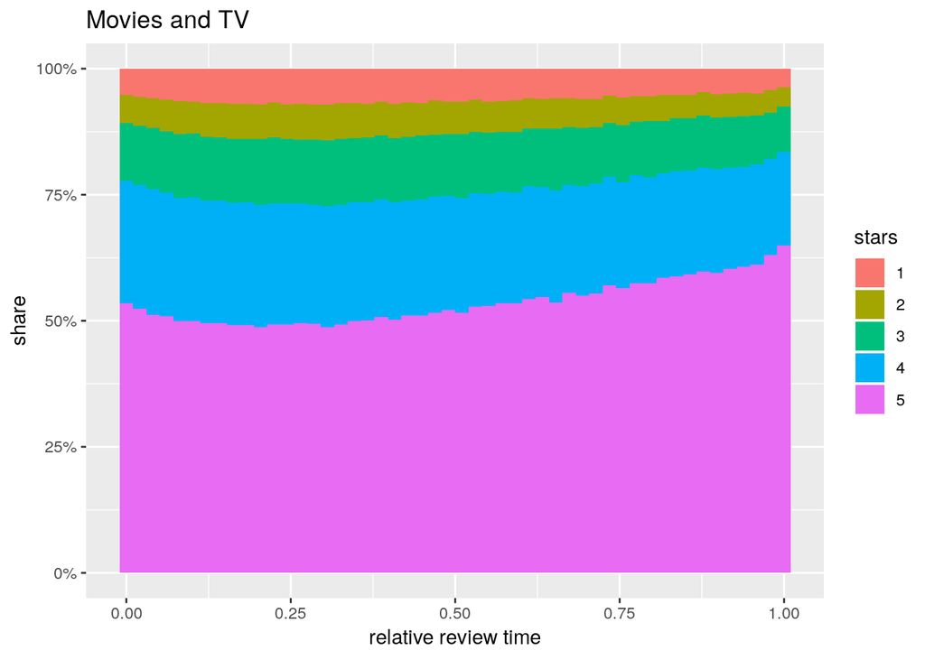

### Positive helpful

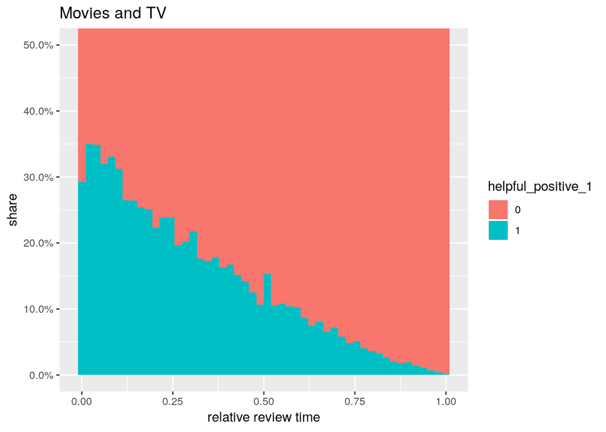

### Negative helpful

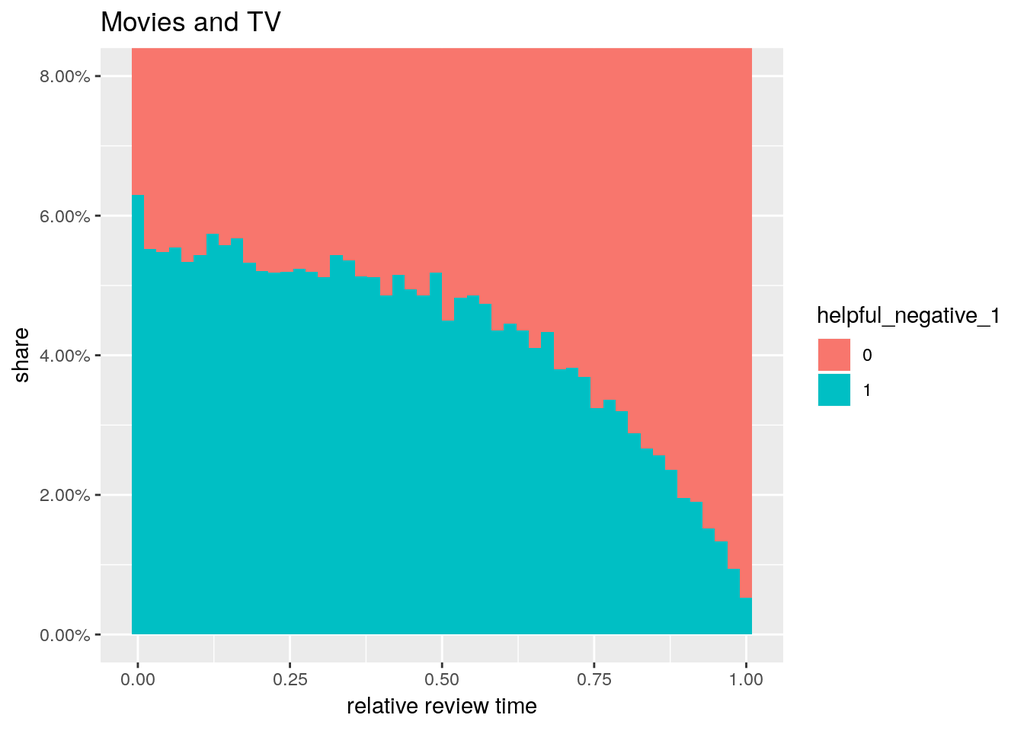

## Price

The product prices distribution:

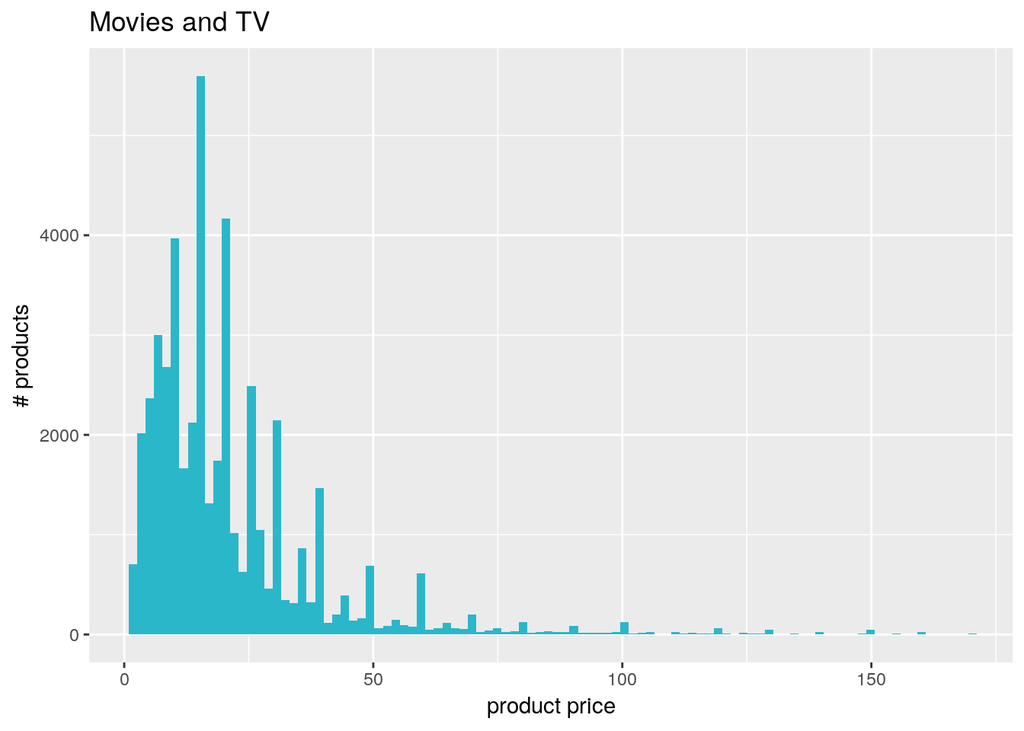

### Stars

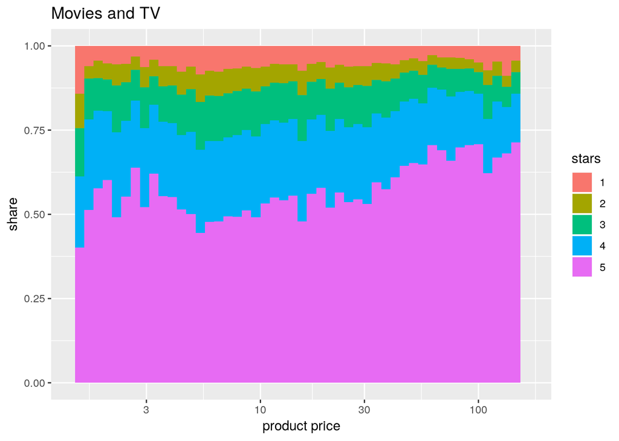

### Positive helpful

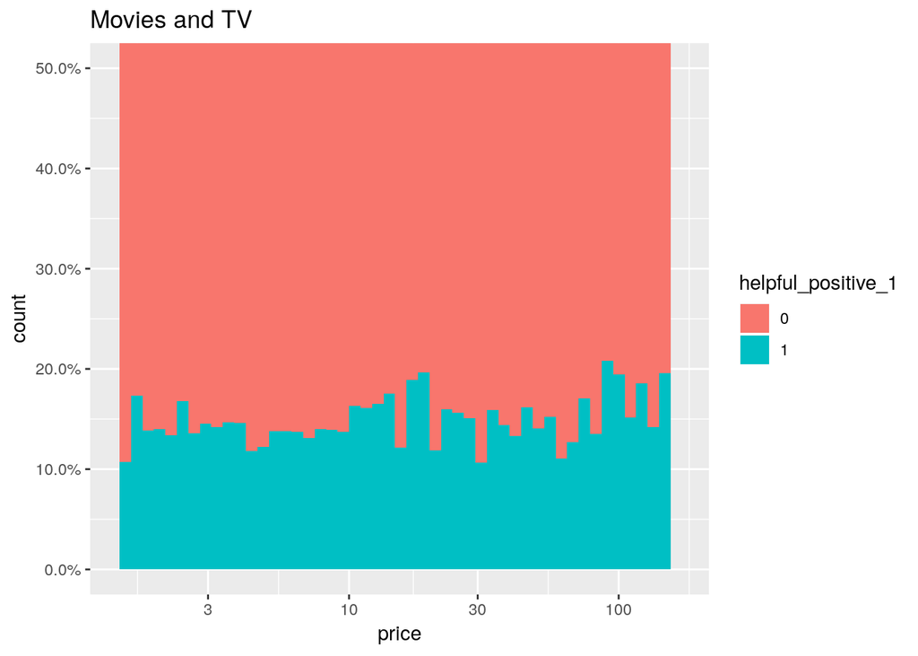

### Negative helpful

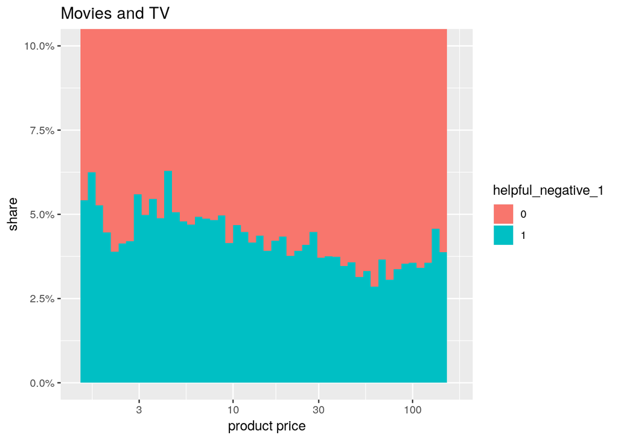

## Per products view

### Number of positive reviews vs total number of reviews

As expected - the more reviews, the more positive reviews. But there are saturation limits as only limited top reviews are shown on each product page.

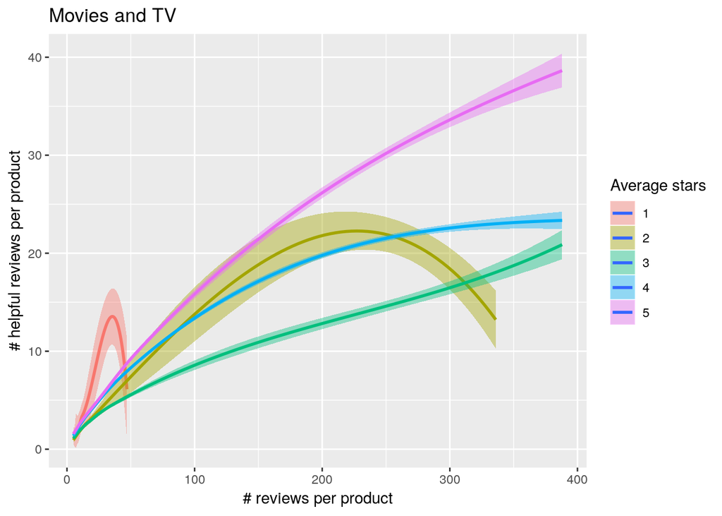

### Reviews per product on price

The higher price, the lower sales are expected. Therefore the lower number of reviews.

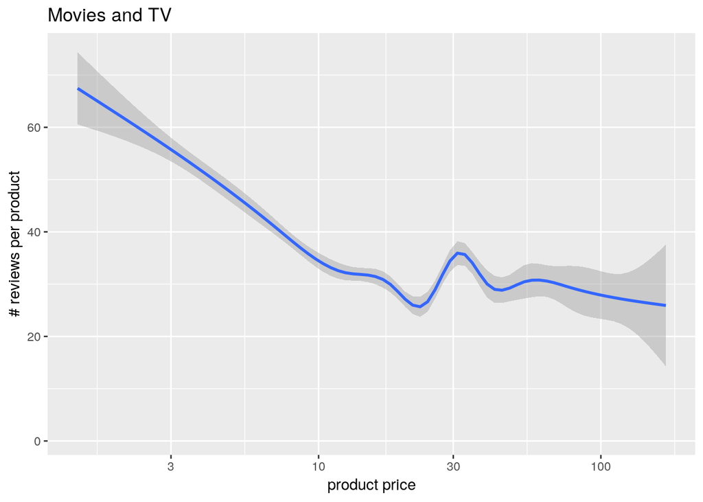

## Product pairs

Attribute “bought_together” in the products metadata shows which products are often bought together (in one basket) with the given product. For each product having this attribute we can calculate average price, review score (stars) and review helpfulness of the related products.

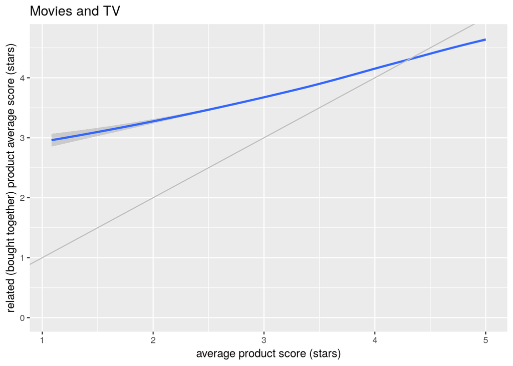

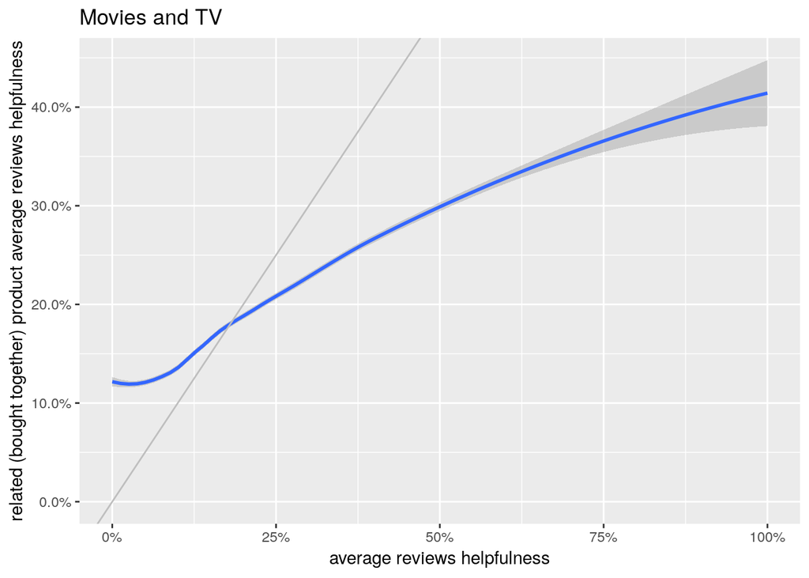